# week4

## Question 7.1

Describe a situation or problem from your job, everyday life, current events, etc., for which exponential smoothing would be appropriate. What data would you need? Would you expect the value of alpha (the first smoothing parameter) to be closer to 0 or 1, and why?

I am a cloud architect by profession and one of the things that I need to do on a regular basis is to work with my customers on their existing footprint and their near-term, long-term resource requirements to come up with a TCO model. Using exponential smoothing I can forecast their near term requirements and come up with a TCO model to prove the economies of scale of the cloud. I would need the following data * resource type (vcpu, ram, ssd etc), * amount of usage by the hour * seasonal spikes based on customer industry

The alpha value will be closer to 1,for an already established business, due to less variance in their resource consumption and growth It will be closer to 0 for an unregulated, new, upcoming business.

## Question 7.2

Using the 20 years of daily high temperature data for Atlanta (July through October) from Question 6.2 (file temps.txt), build and use an exponential smoothing model to help make a judgment of whether the unofficial end of summer has gotten later over the 20 years. (Part of the point of this assignment is for you to think about how you might use exponential smoothing to answer this question. Feel free to combine it with other models if you’d like to. There’s certainly more than one reasonable approach.) Note: in R, you can use either HoltWinters (simpler to use) or the smooth package’s es function (harder to use, but more general). If you use es, the Holt-Winters model uses model=”AAM” in the function call (the first and second constants are used “A”dditively, and the third (seasonality) is used “M”ultiplicatively; the documentation doesn’t make that clear).

```r
weatherdata<- read.table("/Georgia\ Tech/Assignments/ISYE-6501/week4/temps.txt", header = TRUE)
head(weatherdata)
```

```
##     DAY X1996 X1997 X1998 X1999 X2000 X2001 X2002 X2003 X2004 X2005 X2006 X2007
## 1 1-Jul    98    86    91    84    89    84    90    73    82    91    93    95
## 2 2-Jul    97    90    88    82    91    87    90    81    81    89    93    85
## 3 3-Jul    97    93    91    87    93    87    87    87    86    86    93    82
## 4 4-Jul    90    91    91    88    95    84    89    86    88    86    91    86
## 5 5-Jul    89    84    91    90    96    86    93    80    90    89    90    88
## 6 6-Jul    93    84    89    91    96    87    93    84    90    82    81    87
##   X2008 X2009 X2010 X2011 X2012 X2013 X2014 X2015
## 1    85    95    87    92   105    82    90    85
## 2    87    90    84    94    93    85    93    87
## 3    91    89    83    95    99    76    87    79
## 4    90    91    85    92    98    77    84    85
## 5    88    80    88    90   100    83    86    84
## 6    82    87    89    90    98    83    87    84
```

Now lets convert the matrix into a timeseries object to be used within our forecasting model

```r
#Convert to vector before converting to a time series object
weatherdata_vec<-as.vector(unlist(weatherdata[,-1]))
m<-dim(weatherdata)[1]
n<-dim(weatherdata)[2]

#Lets choose years 1996-2012 as training data
#1996-2012
ntrain=(n-4)*m

train<-weatherdata_vec[1:ntrain]

#remaining is test data
test<-tail(weatherdata_vec, -(ntrain))

#ts object for the entire dataset
weatherts <- ts(weatherdata_vec, start=c(1996, 7), frequency = 123)
#1996-2012
weatherts_train <- window(weatherts, end = c(2013, 10))
#2013 onwards, test data to verify the accuracy
weatherts_test <- window(weatherts, start = c(2014, 7))
```

### Holt-winters

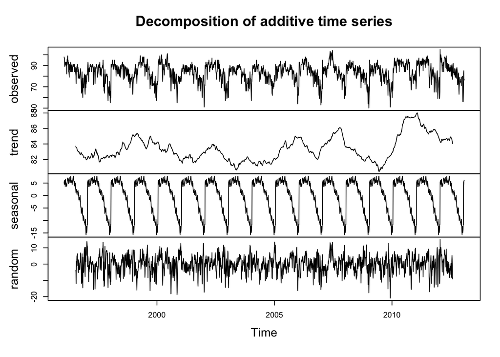

```r
printf <- function(...)print(sprintf(...))

require(graphics)
library(ModelMetrics)
#Look at the seasonality and trend of the data
library(forecast)
components.ts = decompose(weatherts_train)
plot(components.ts)
```

Lets look at the moving average of the trend to understand how temperature is progressing over the years

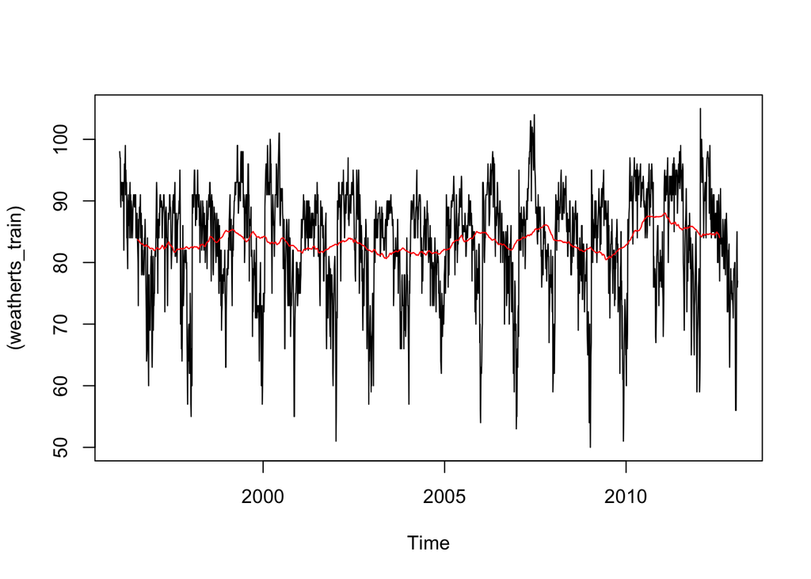

```r
library(forecast)

trend_weather = ma(weatherts_train, order = 123, centre = T)
plot((weatherts_train))
lines(trend_weather, col="red")
```

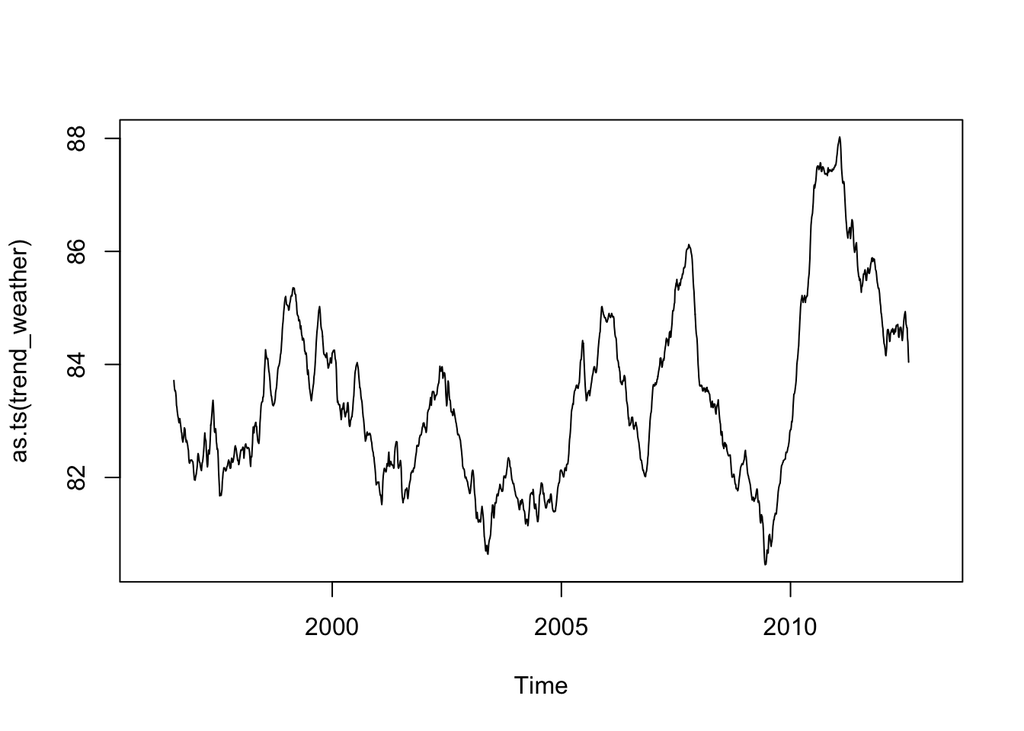

```r
plot(as.ts(trend_weather))
```

```r
# fit a multiplicative seasonal exponential smoothing model
model <- HoltWinters(weatherts_train, gamma=NULL, seasonal = "mult", beta=FALSE)
test.fit<-predict(model,n.ahead = length(weatherts_test))
#calculate the RMSE
rmse_val <- rmse(weatherts_test,test.fit)
printf(" RMSE = %s",rmse_val)
```

```
## [1] " RMSE = 19.937780676186"
```

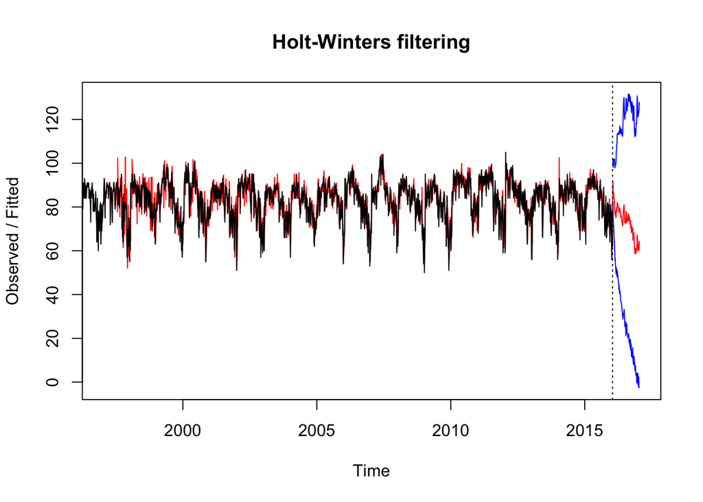

```r
fit_complete <- HoltWinters(weatherts, gamma=NULL, seasonal = "mult",beta=FALSE)
f2016<- predict(fit_complete, n.ahead=123 , prediction.interval = TRUE)
require(graphics)
plot(fit_complete, f2016)
```

```r
library(tsbox)
df<-ts_df(f2016)


#Append the fitted values to the original data
weatherdata_hw<-cbind.data.frame(weatherdata,df$value[1:123])
colnames(weatherdata_hw)[22]<-"X2016"

head(weatherdata_hw)
```

```
##     DAY X1996 X1997 X1998 X1999 X2000 X2001 X2002 X2003 X2004 X2005 X2006 X2007
## 1 1-Jul    98    86    91    84    89    84    90    73    82    91    93    95
## 2 2-Jul    97    90    88    82    91    87    90    81    81    89    93    85
## 3 3-Jul    97    93    91    87    93    87    87    87    86    86    93    82
## 4 4-Jul    90    91    91    88    95    84    89    86    88    86    91    86
## 5 5-Jul    89    84    91    90    96    86    93    80    90    89    90    88
## 6 6-Jul    93    84    89    91    96    87    93    84    90    82    81    87
##   X2008 X2009 X2010 X2011 X2012 X2013 X2014 X2015    X2016
## 1    85    95    87    92   105    82    90    85 91.29205
## 2    87    90    84    94    93    85    93    87 90.94675
## 3    91    89    83    95    99    76    87    79 85.43243
## 4    90    91    85    92    98    77    84    85 86.59186
## 5    88    80    88    90   100    83    86    84 86.30419
## 6    82    87    89    90    98    83    87    84 84.80810
```

Apply cusum method to find out if the unofficial summer end has moved further. Repurposing the cusum method from Homework3

```r
cusum_weather <- function(weatherdata) {
#Calculate the mean for the summer months July, August and 15 days of september first 77 rows
weathermeans<-colMeans(weatherdata[1:77,-1])
summermean<-mean(weathermeans)

#Calculate the standard deviation for the summer months July, August and 15 days of september first 77 rows
Sdmatrix<- apply(weatherdata[1:77,-1],2,sd)
meanSd<-mean(Sdmatrix)

#we are trying to find when unofficial summer ends,i.e. decreasing change, so St=max(0,S{t-1}+(mu-xt-C))

#Calculate Xt-Mu for every year
xt_mu<-apply(weatherdata[,-1],1,'-',weathermeans)

#reverse signs i.e. mu-Xt since we are tracking decrease
mu_xt <- (apply(xt_mu,1,'*',-1))

#Lets set C = 0.5 of SD
C<-Sdmatrix*0.5

# subract C
mu_xt_c <-apply(mu_xt,1,'-',C)
mu_xt_c<-t(mu_xt_c)

#dimensions of the matrix for declaring St matrix
m<-dim(mu_xt)[1]
n<-dim(mu_xt)[2]

#St matrix declaration
St<-matrix(rep(0),nrow=m,ncol=n)

#Calculate St, cusum
for( j in 1:n){
  St_1<-0
  for(i in 1:m){
    St_1<- max(0,St_1+as.numeric(mu_xt_c[i,j]))
    St[i,j]<-St_1
  }
}

#set column names and also append the "day of the month" information
colnames(St)<-colnames(weatherdata[,-1])
St<-cbind(as.matrix(weatherdata[,1]),St)

colnames(St)[1] <- "Day"

#Lets choose an Threshold of 7 * Standard Deviation

Thold<-(Sdmatrix * 7)

#Find unofficial summer ends for each year
summermat<-matrix(nrow=2,ncol=n)
dim(summermat)
colnames(summermat)<-colnames(weatherdata[,-1])

#recalculate the dimensions
ms<-dim(St)[1]
ns<-dim(St)[2]

#Find the tip-over point i.e. the change in temperature for every year
# go column by column, i.e. year by year
for (j in 2:ns){

# go row by row, i.e. day by day
  for(i in 1:ms){
    dayVal<-as.numeric(St[i,j])
    Th<-Thold[j-1]
    if( dayVal > Th ) {

      summermat[1,j-1]<- St[i,1]
      summermat[2,j-1]<- weatherdata[i,j]
      break
    }

  }
}

# When Summer unofficially ends
summermat<-t(summermat)
colnames(summermat)<-c("Day","Temperature")
return(summermat)
}
```

When summer really ends for 2016

```r
cusum_weather(weatherdata_hw)
```

```
##       Day      Temperature
## X1996 "16-Sep" "82"
## X1997 "25-Sep" "66"
## X1998 "21-Sep" "82"
## X1999 "14-Jul" "81"
## X2000 "7-Sep"  "66"
## X2001 "3-Sep"  "73"
## X2002 "1-Sep"  "84"
## X2003 "10-Sep" "79"
## X2004 "15-Sep" "73"
## X2005 "6-Oct"  "72"
## X2006 "13-Sep" "70"
## X2007 "19-Sep" "82"
## X2008 "27-Aug" "80"
## X2009 "3-Sep"  "79"
## X2010 "28-Sep" "76"
## X2011 "7-Sep"  "69"
## X2012 "13-Sep" "81"
## X2013 "17-Aug" "66"
## X2014 "23-Sep" "77"
## X2015 "13-Sep" "75"
## X2016 "21-Sep" "70.3973268047912"
```

Based on the above table values for 2016, we see that the summer has not really moved far off from the usual.

Lets look at forecasting using ARIMA.

```r
arima_model<-auto.arima(weatherts_train)
test.fit<-predict(arima_model,n.ahead = length(weatherts_test))

printf("RMSE Arima = %s", rmse(weatherts_test,test.fit$pred))
```

```
## [1] "RMSE Arima = 7.10294594049641"
```

RMSE of 7.1, hence much better accuracy than Holtwinters. Lets find out what the fitted value for 2016 look like

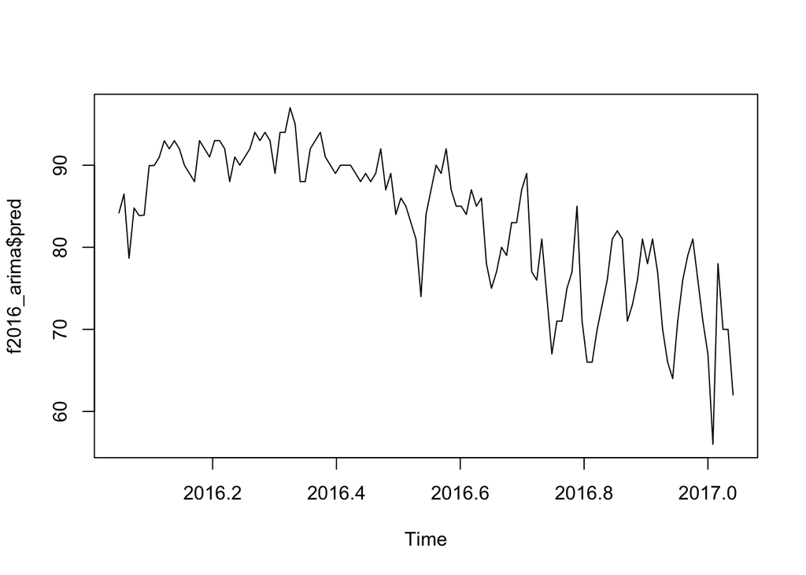

```r
arima_model<-auto.arima(weatherts)

f2016_arima<- predict(arima_model, n.ahead=123 , prediction.interval = TRUE)

require(graphics)
plot(f2016_arima$pred)
```

The graph shows that not a great change in temperature in the summer months compared to previous years

```r
#inlcude tsbox for converting functions
library(tsbox)
df<-ts_df(f2016_arima$pred)

#Append the fitted values to the original data
weatherdata_arima<-cbind.data.frame(weatherdata,df$value)
colnames(weatherdata_arima)[22]<-"X2016"

head(weatherdata_arima)
```

```
##     DAY X1996 X1997 X1998 X1999 X2000 X2001 X2002 X2003 X2004 X2005 X2006 X2007
## 1 1-Jul    98    86    91    84    89    84    90    73    82    91    93    95
## 2 2-Jul    97    90    88    82    91    87    90    81    81    89    93    85
## 3 3-Jul    97    93    91    87    93    87    87    87    86    86    93    82
## 4 4-Jul    90    91    91    88    95    84    89    86    88    86    91    86
## 5 5-Jul    89    84    91    90    96    86    93    80    90    89    90    88
## 6 6-Jul    93    84    89    91    96    87    93    84    90    82    81    87
##   X2008 X2009 X2010 X2011 X2012 X2013 X2014 X2015    X2016
## 1    85    95    87    92   105    82    90    85 84.19095
## 2    87    90    84    94    93    85    93    87 86.48031
## 3    91    89    83    95    99    76    87    79 78.66618
## 4    90    91    85    92    98    77    84    85 84.78557
## 5    88    80    88    90   100    83    86    84 83.86227
## 6    82    87    89    90    98    83    87    84 83.91153
```

Call cusum function to figure out if unofficial summer has moved further

```r
cusum_weather(weatherdata_arima)
```

```
##       Day      Temperature
## X1996 "16-Sep" "82"
## X1997 "25-Sep" "66"
## X1998 "21-Sep" "82"
## X1999 "14-Jul" "81"
## X2000 "7-Sep"  "66"
## X2001 "3-Sep"  "73"
## X2002 "1-Sep"  "84"
## X2003 "10-Sep" "79"
## X2004 "15-Sep" "73"
## X2005 "6-Oct"  "72"
## X2006 "13-Sep" "70"
## X2007 "19-Sep" "82"
## X2008 "27-Aug" "80"
## X2009 "3-Sep"  "79"
## X2010 "28-Sep" "76"
## X2011 "7-Sep"  "69"
## X2012 "13-Sep" "81"
## X2013 "17-Aug" "66"
## X2014 "23-Sep" "77"
## X2015 "13-Sep" "75"
## X2016 "13-Sep" "75"
```

Arima model too does not indicate that the unofficial summer has moved further Hence we can conclude the unofficial summer has not moved to later dates compared to the last few years